# Coming of Age Under Trump: Online Appendix

Author

Nikolaos Vichos

## Introduction

This document is the online appendix for the paper “Coming of Age Under Trump The Effect of First Electoral Exposure in a Trump Election on Long-Term Support for Radical Right Attitudes.” Here I have included additional, mainly methodological, details not included in the main body of the paper.

## Regression Design

Since linear models estimated via ordinary least squares may miss subtle non-linearities in how the outcome evolves with age, I estimate a more flexible version of the RDD.[^1] This can be expressed as:

$$Y_i = \alpha + \tau D_i + f(X_i - c) + \varepsilon_i$$

Where:

- $Y_i$ is the outcome. There are three possible outcomes: three different indices measuring support for nativism, authoritarianism, or populism.
- $D_i$ is an indicator equal to 1 if individual $i$’s age *exceeds* the cutoff (i.e., they were just *eligible* to vote in 2012), and 0 otherwise.[^2]
- $\tau$ is the parameter of interest, capturing the size of the discontinuity at the threshold—that is, the causal effect of being first eligible to vote in 2012 rather than in 2016.
- $X_i$ is the running variable, the respondent’s age in years in 2020.
- $f(X_i - c)$ denotes a flexible function (e.g., first- or second-order polynomial) of the centered running variable—distance from the cutoff $c$.
- $c = 26$ is the cutoff point, so $X_i - c$ represents the running variable centered at the threshold.
- $\varepsilon_i$ is an error term.

In my analysis, I estimated a series of sharp RD models using local polynomial regression. Each model used local linear estimation (polynomial order = 1) and MSE-optimal bandwidth selection to obtain the treatment effect at the cutoff.

## Index Construction

This section documents the construction of the indices, including item wording, internal consistency, factor structure, and rescaling.

### Item Wordings

The tables below provided the exact question wording for each item included in the indices. Most responses were in a 5- or 7-point Likert scale.

Nativist Items and Survey Wording

| Shortened Name | Survey Question |
| --- | --- |
| Minorities Should Adapt | Minorities should adapt to the customs and traditions of the United States. |
| World Like America | The world would be a better place if people from other countries were more like Americans |
| America Is Better | Generally speaking, is the United States better, worse, or about the same as most other countries? |
| Immigrants Harm Culture | America’s culture is generally harmed by immigrants. |

Authoritarian Items and Survey Wording

[output not shown]

Populist Items and Survey Wording

[output not shown]

### Internal Consistency

To evaluate the internal reliability of the items used in the indices, I computed Cronbach’s α for each set of items.

Internal Consistency (Standardized Cronbach’s Alpha) for Liberal Items

| Set of Items | Cronbach’s α (raw) | Cronbach’s α (standardized) |
| --- | --- | --- |
| Nativism | 0.67 | 0.67 |
| Authoritarianism | 0.82 | 0.82 |
| Populism | 0.83 | 0.83 |

Though the authoritarianism and populism items show acceptable internal consistency (α > 0.7), both the raw and the standardized alpha for the nativism items are just below the commonly accepted threshold (Taber 2018). Even though the index was eventually constructed due to the theoretical importance of nativism, this lack of internal consistency raises an important question-mark regarding the construction validity of the nativism index.

### Factor Structure

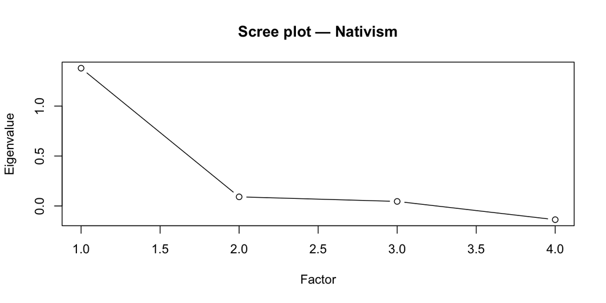

Figure 1: Scree Plot: Eigenvalues for Nativism Factors)

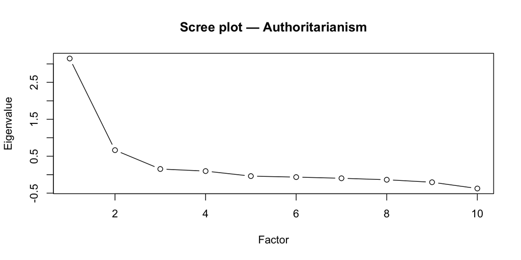

Figure 2: Scree Plot: Eigenvalues for Authoritarianism Factors)

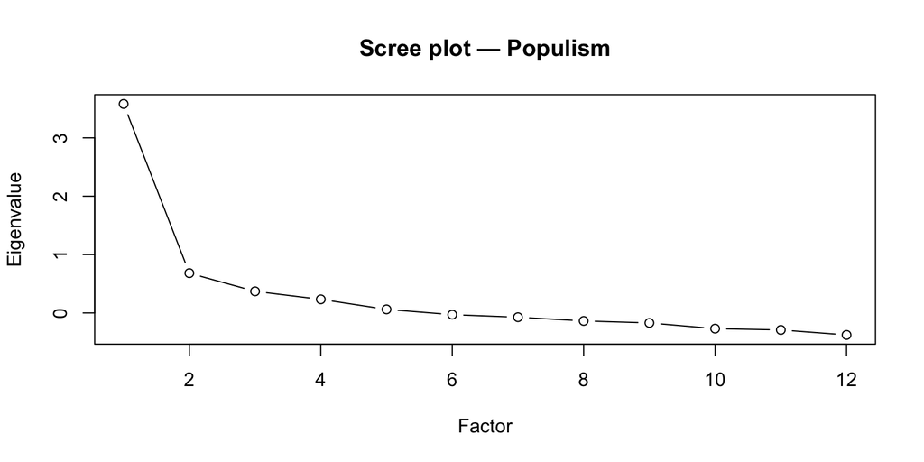

Figure 3: Scree Plot: Eigenvalues for Populism Factors)

### Index Rescaling

Each index is constructed by extracting individual scores on the first factor and rescaling them to range from 0 to 1 using min–max normalization. Even though higher values indicate *lower* endorsement for radical right attitudes during the process of index construction, this is for visualization and interpretability purposes, due to the specific design of the rdrobust package (Calonico, Cattaneo, and Farrell 2025). In the package, the threshold is “crossed” from left to right—hence, normally, a positive effect would suggest an increase in nativist, authoritarian, or populist attitudes among those who voted for the first time in *2012.* However, for clearer comprehension, the results have been reversed, and the indices can be interpreted as indicating *decreasing* support for each of the three ideological features. However, strictly speaking, the indices indicate the opposite direction in their construction. For details on the process of index construction, refer to the replication code file.

## RD Results

The detailed estimates of the RDD are shown below in table format.

Regression Discontinuity Estimates on Radical Right Support

| Sample | Model | Estimate | SE | Bandwidth Type | Bandwidth (h) | N | Outcome |
| --- | --- | --- | --- | --- | --- | --- | --- |
| Full Sample | Without Controls | 0.007 | 0.022 | MSE-optimal | 8.90 | 980 | Populism |
| Full Sample | With Controls | 0.003 | 0.022 | MSE-optimal | 8.96 | 961 | Populism |
| Independents | Without Controls | 0.002 | 0.034 | MSE-optimal | 9.41 | 388 | Populism |
| Independents | With Controls | -0.019 | 0.034 | MSE-optimal | 9.27 | 378 | Populism |
| Partisans | Without Controls | -0.005 | 0.029 | MSE-optimal | 9.01 | 617 | Populism |
| Partisans | With Controls | 0.006 | 0.029 | MSE-optimal | 9.12 | 608 | Populism |
| Democrats | Without Controls | 0.031 | 0.035 | MSE-optimal | 8.87 | 339 | Populism |
| Democrats | With Controls | 0.046 | 0.034 | MSE-optimal | 9.03 | 366 | Populism |
| Republicans | Without Controls | -0.050 | 0.052 | MSE-optimal | 8.63 | 232 | Populism |
| Republicans | With Controls | -0.038 | 0.052 | MSE-optimal | 8.72 | 228 | Populism |
| Full Sample | Without Controls | 0.005 | 0.028 | MSE-optimal | 9.04 | 957 | Authoritarianism |
| Full Sample | With Controls | 0.009 | 0.027 | MSE-optimal | 8.68 | 860 | Authoritarianism |
| Independents | Without Controls | 0.088 | 0.042 | MSE-optimal | 8.98 | 312 | Authoritarianism |
| Independents | With Controls | 0.064 | 0.041 | MSE-optimal | 9.37 | 333 | Authoritarianism |
| Partisans | Without Controls | -0.012 | 0.039 | MSE-optimal | 8.33 | 519 | Authoritarianism |
| Partisans | With Controls | 0.021 | 0.037 | MSE-optimal | 8.31 | 511 | Authoritarianism |
| Democrats | Without Controls | 0.005 | 0.041 | MSE-optimal | 8.91 | 310 | Authoritarianism |
| Democrats | With Controls | 0.041 | 0.038 | MSE-optimal | 8.93 | 306 | Authoritarianism |
| Republicans | Without Controls | -0.115 | 0.050 | MSE-optimal | 8.31 | 209 | Authoritarianism |
| Republicans | With Controls | -0.107 | 0.050 | MSE-optimal | 8.57 | 205 | Authoritarianism |
| Full Sample | Without Controls | -0.064 | 0.029 | MSE-optimal | 8.32 | 988 | Nativism |
| Full Sample | With Controls | -0.054 | 0.029 | MSE-optimal | 8.01 | 969 | Nativism |
| Independents | Without Controls | -0.060 | 0.039 | MSE-optimal | 8.65 | 355 | Nativism |
| Independents | With Controls | -0.058 | 0.039 | MSE-optimal | 8.19 | 345 | Nativism |
| Partisans | Without Controls | 0.000 | 0.040 | MSE-optimal | 9.13 | 623 | Nativism |
| Partisans | With Controls | 0.040 | 0.039 | MSE-optimal | 9.12 | 614 | Nativism |
| Democrats | Without Controls | -0.009 | 0.044 | MSE-optimal | 8.95 | 342 | Nativism |
| Democrats | With Controls | 0.036 | 0.042 | MSE-optimal | 9.21 | 369 | Nativism |
| Republicans | Without Controls | -0.016 | 0.058 | MSE-optimal | 8.81 | 235 | Nativism |
| Republicans | With Controls | 0.005 | 0.059 | MSE-optimal | 8.86 | 231 | Nativism |

## Discontinuity Plots

In this section, I include all 15 of the discontinuity plots, organized by the specific subgroup to which they refer

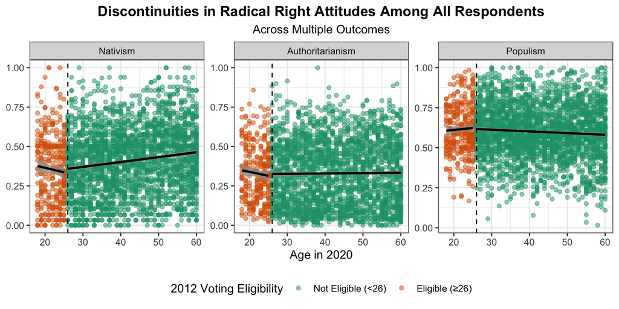

Figure 4: Discontinuity in Liberal Attitudes at Age 26 (Full Sample, First Degree Polynomial)

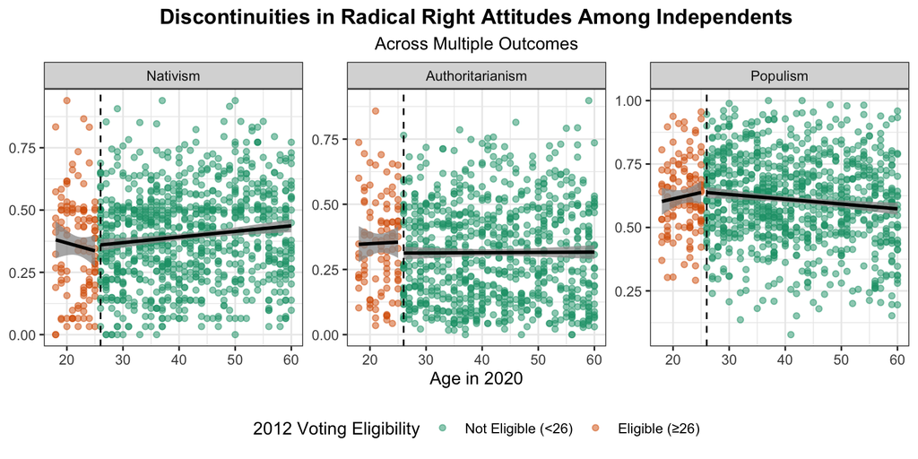

Figure 5: Discontinuity in Liberal Attitudes at Age 26 (Independents Subgroup, First Degree Polynomial)

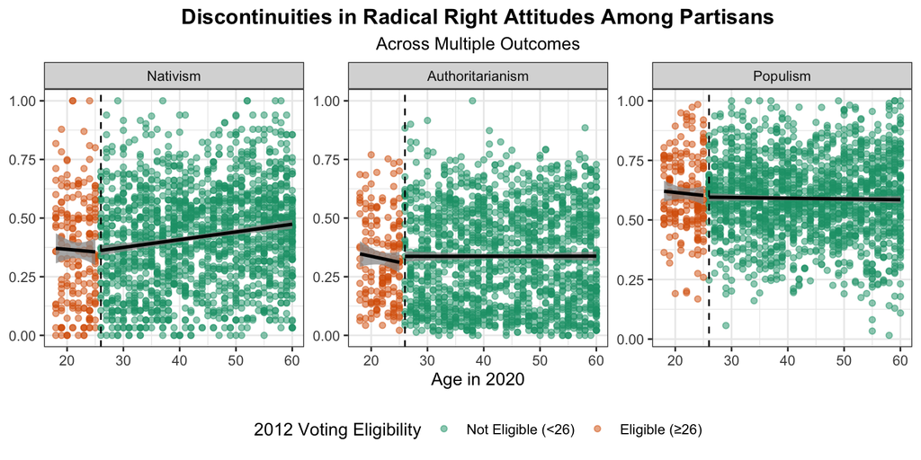

Figure 6: Discontinuity in Liberal Attitudes at Age 26 (Partisan Subgroup, First Degree Polynomial)

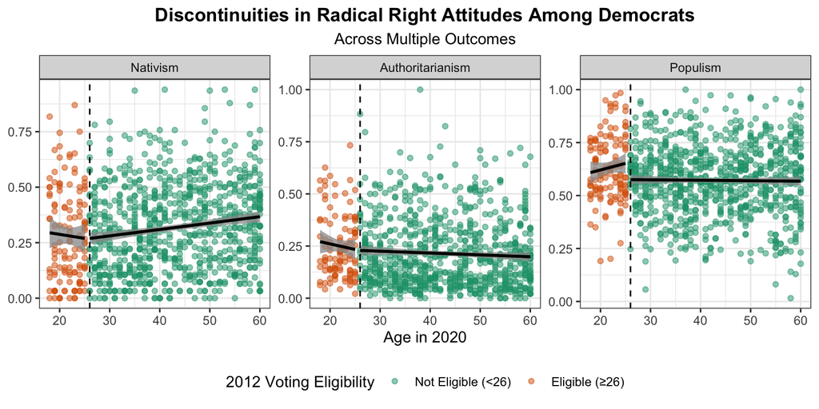

Figure 7: Discontinuity in Liberal Attitudes at Age 26 (Democrat Subgroup, First Degree Polynomial)

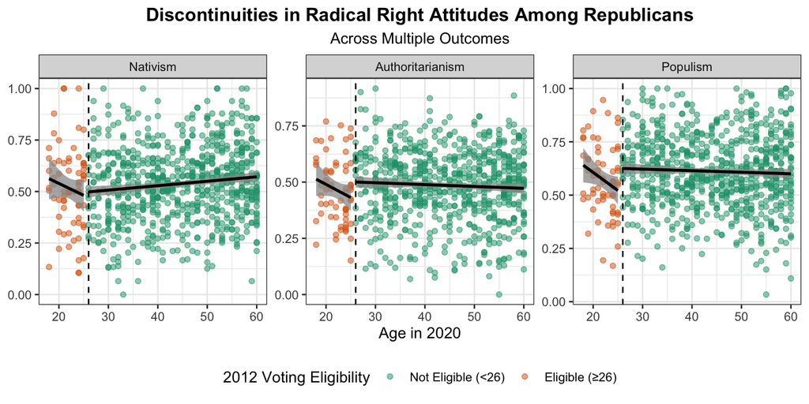

Figure 8: Discontinuity in Liberal Attitudes at Age 26 (Republican Subgroup, First Degree Polynomial)

## Robustness Checks

I present the robustness checks conducted the two models (Simple vs Controls) and for the three different RD estimates (Conventional, Bias-Adjusted, Bias-Adjusted with Robust SEs). I first present them for the full sample and then for the different subgroup. Due to their large number, however, they are quite difficult to navigate.

To narrow them down a bit I only focus on outcomes where there was at least one significant result (i.e., *not* populism) and across groups that also had at least one significant result (i.e., *not* partisans or democrats)

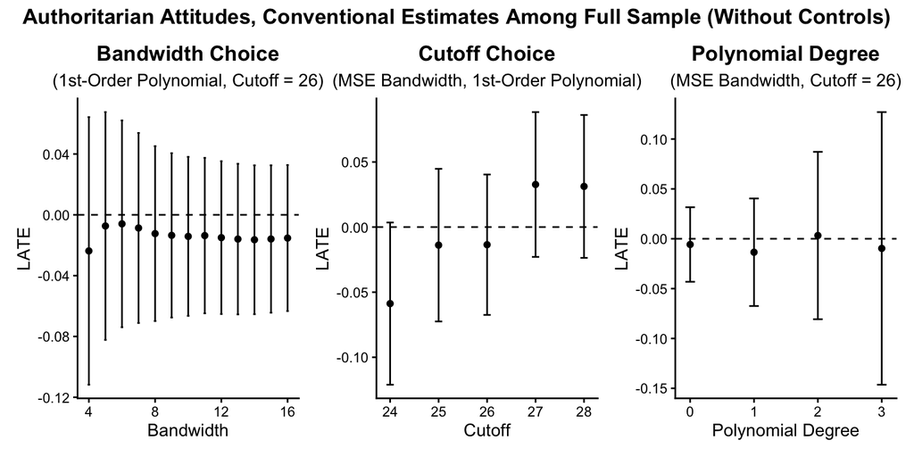

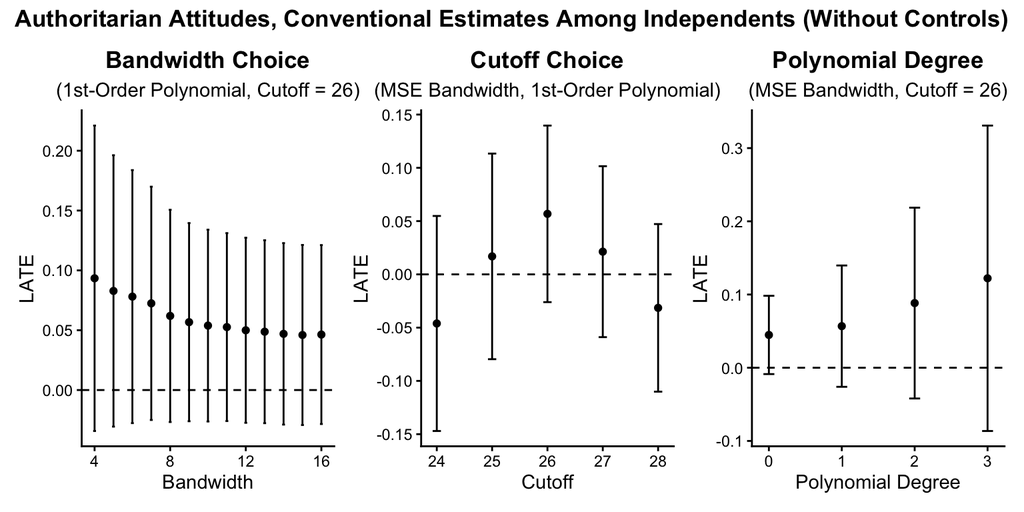

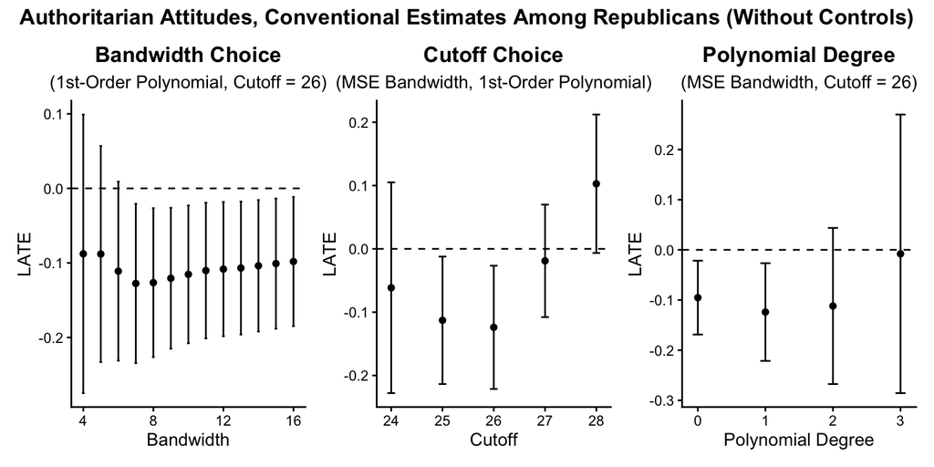

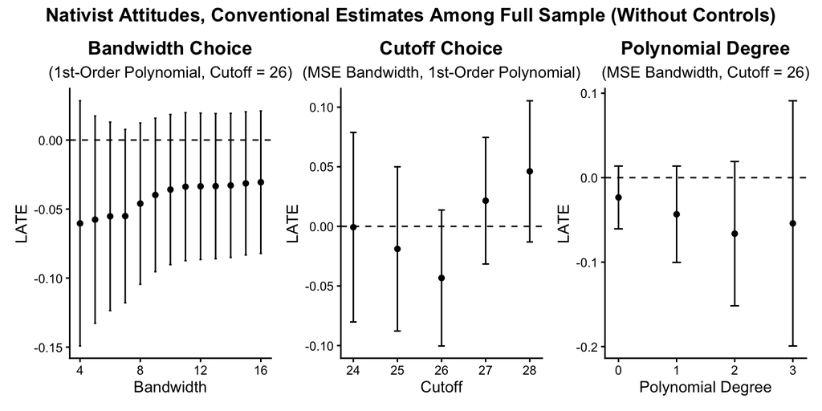

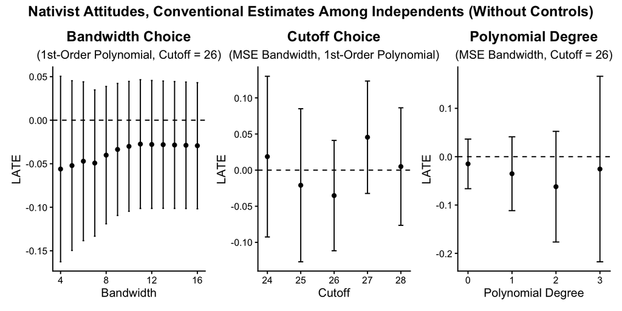

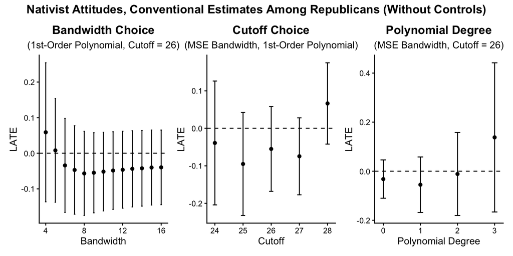

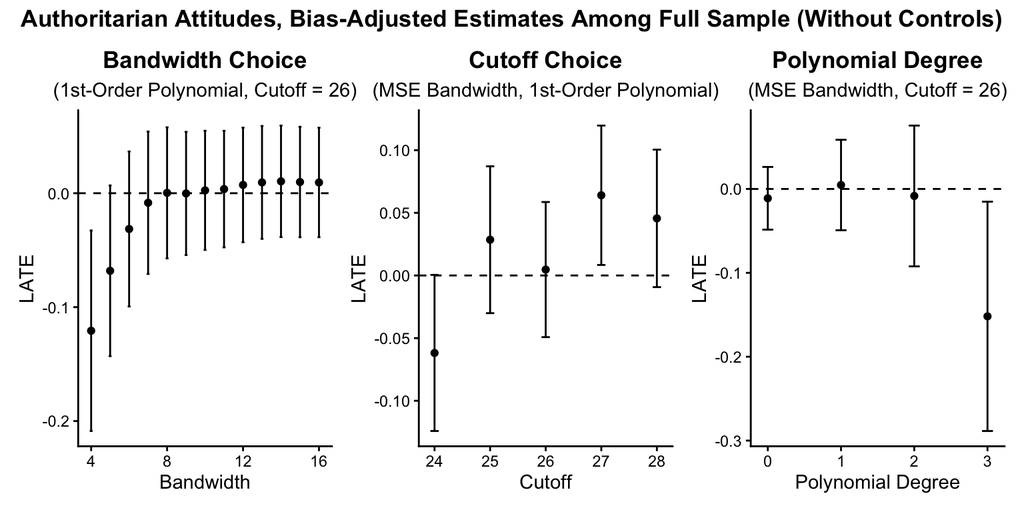

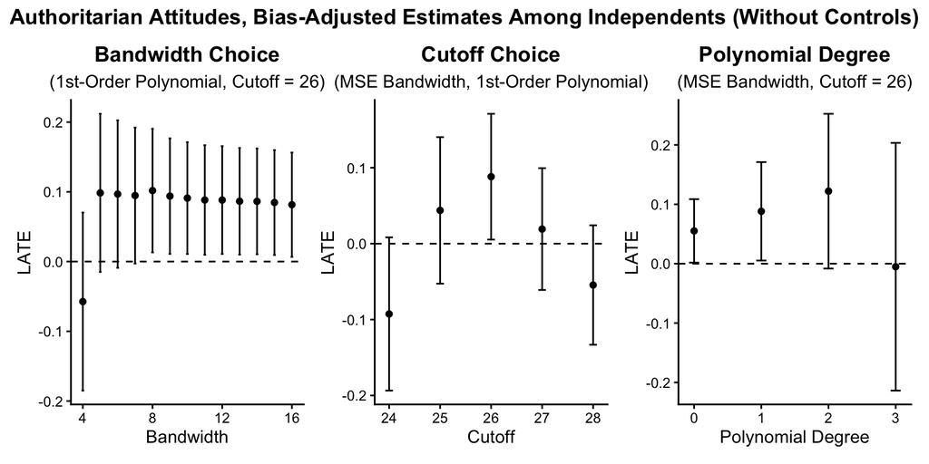

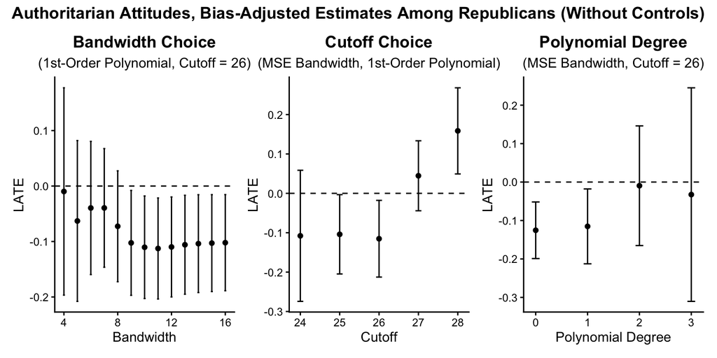

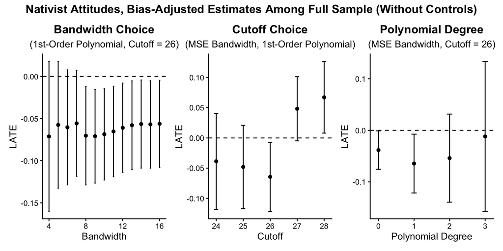

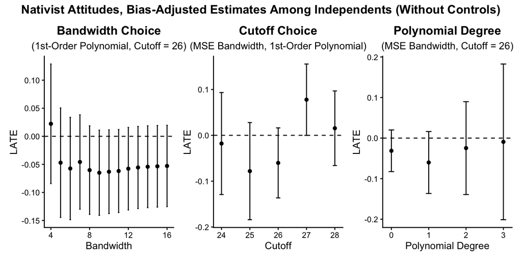

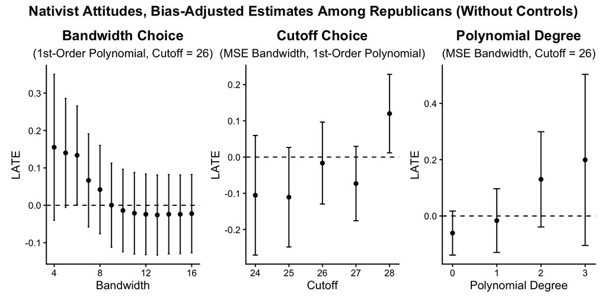

[24 more figures not shown]

## References

Calonico, Sebastian, Matias D. Cattaneo, and Max H. Farrell. 2025. *Rdrobust: Robust Data-Driven Statistical Inference in Regression-Discontinuity Designs*. https://cran.r-project.org/web/packages/rdrobust/index.html.

Taber, Keith S. 2018. “The Use of Cronbach’s Alpha When Developing and Reporting Research Instruments in Science Education.” *Research in Science Education* 48 (6): 12731296. https://doi.org/10.1007/s11165-016-9602-2.

## Footnotes

[^1]: Of course, this version can take a linear form; however, it is also generalizable to higher polynomial degrees.
[^2]: This might seem counter-intuitive, since the group of interest (young voters) becomes, in a sense, the ‘control group’. This is due to the specific design of the R package used (rdrobust), which estimates causal effects when the running variable crosses the cut-off.